# Tugas Pertemuan 3

Gemala Aleida Fitri G1401231070

2025-09-18

## *Packages*

```r
library(dynlm)
library(MLmetrics)
library(lmtest)
library(car)
library(dLagM)
```

## Impor Data

```r
dt <- read.csv("C:/Users/Ainul Hayati/Documents/kuliah/Departemen/Semester 5/Metode Peramalan Deret Waktu/Praktikum MPDW/NewDelhi_Air_quality.csv")
str(dt)
```

```
## 'data.frame':    72 obs. of  12 variables:
##  $ X              : int  0 1 2 3 4 5 6 7 8 9 ...
##  $ AQI            : num  30.2 28.2 26.6 25 26 26 26 24 23 24 ...
##  $ CO             : num  199 198 199 202 205 ...
##  $ datetime       : chr  "2022-10-21:18" "2022-10-21:19" "2022-10-21:20" "2022-10-21:21" ...
##  $ no2            : num  0.0469 0.0465 0.0469 0.0482 0.0489 ...
##  $ o3             : num  55.8 54.9 54.6 55.1 55.8 ...
##  $ pm10           : num  10.5 10.7 11.2 11.1 10.4 ...
##  $ pm25           : num  5.64 4.62 3.52 2.23 1.98 ...
##  $ so2            : num  0.387 0.41 0.402 0.376 0.339 ...
##  $ timestamp_local: chr  "2022-10-21T23:00:00" "2022-10-22T00:00:00" "2022-10-22T01:00:00" "2022-10-22T02:00:00" ...
##  $ timestamp_utc  : chr  "2022-10-21T18:00:00" "2022-10-21T19:00:00" "2022-10-21T20:00:00" "2022-10-21T21:00:00" ...
##  $ ts             : int  1666375200 1666378800 1666382400 1666386000 1666389600 1666393200 1666396800 1666400400 1666404000 1666407600 ...
```

```r
data <- dt[,c(2,6)]
data
```

```
##     AQI       o3
## 1  30.2 55.78995
## 2  28.2 54.93164
## 3  26.6 54.64554
## 4  25.0 55.07469
## 5  26.0 55.78995
## 6  26.0 56.50520
## 7  26.0 55.78995
## 8  24.0 52.92892
## 9  23.0 50.06790
## 10 24.0 51.49841
## 11 25.0 53.64418
## 12 26.0 55.78995
## 13 27.0 59.36623
## 14 29.0 62.22725
```

[output cut: 58 more lines]

## Pembagian Data

```r
#SPLIT DATA
train<-data[1:54,]
test<-data[55:72,]
```

```r
#data time series
train.ts<-ts(train)
test.ts<-ts(test)
data.ts<-ts(data)
```

## Model Koyck

```r
#MODEL KOYCK
model.koyck <- koyckDlm(x = train$o3, y = train$AQI)
summary(model.koyck)
```

```
##
## Call:
## "Y ~ (Intercept) + Y.1 + X.t"
##
## Residuals:
##       Min        1Q    Median        3Q       Max
## -1.135845 -0.266174  0.005908  0.250093  1.063969
##
## Coefficients:
##             Estimate Std. Error t value Pr(>|t|)
## (Intercept)  0.61475    0.92829   0.662    0.511
## Y.1          0.40694    0.07979   5.100 5.25e-06 ***
## X.t          0.26339    0.03991   6.600 2.54e-08 ***
## ---
## Signif. codes:  0 '***' 0.001 '**' 0.01 '*' 0.05 '.' 0.1 ' ' 1
##
## Residual standard error: 0.5015 on 50 degrees of freedom
## Multiple R-Squared: 0.9489,  Adjusted R-squared: 0.9468
## Wald test: 423.5 on 2 and 50 DF,  p-value: < 2.2e-16
##
## Diagnostic tests:
## NULL
##
##                             alpha      beta       phi
## Geometric coefficients:  1.036564 0.2633856 0.4069377
```

```r
AIC(model.koyck)
```

```
## [1] 82.16805
```

```r
BIC(model.koyck)
```

```
## [1] 90.04921
```

Peubah $o3_t$ dan $AQI_{t-1}$ memiliki nilai $P-Value<0.05$. Artinya peubah $o3_t$ dan $AQI_{t-1}$ berpengaruh signifikan terhadap $AQI$. Model keseluruhannya sebagai berikut

$$\hat{AQI_t}=0.6147+0.2633o3_t+0.4069AQI_{t-1}$$

Peramalan AQI untuk 18 periode kedepan menggunakan model koyck

```r
fore.koyck <- forecast(model = model.koyck, x=test$o3, h=18)
fore.koyck
```

```
## $forecasts
##  [1] 27.04989 26.69341 25.79480 24.48718 23.20150 22.01896 21.16096 20.24664
##  [9] 19.78038 20.06161 20.74121 21.01777 21.13031 21.64708 23.17609 24.92863
## [17] 26.39536 27.36900
##
## $call
## forecast.koyckDlm(model = model.koyck, x = test$o3, h = 18)
##
## attr(,"class")
## [1] "forecast.koyckDlm" "dLagM"
```

```r
mape.koyck <- MLmetrics::MAPE(as.numeric(fore.koyck$forecasts),
                              as.numeric(test$AQI))
mape.koyck #data test
```

```
## [1] 0.03065559
```

```r
#akurasi data training
GoF(model.koyck)
```

```
##              n       MAE           MPE       MAPE      sMAPE      MASE
## model.koyck 53 0.3803495 -0.0004837724 0.01415837 0.01413376 0.5957281
##                   MSE      MRAE    GMRAE
## model.koyck 0.2372882 634632166 8967.964
```

## Regression with Distributed Lag

```r
model.dlm <- dlm(x = train$o3,y = train$AQI , q = 2)
summary(model.dlm)
```

```
##
## Call:
## lm(formula = model.formula, data = design)
##
## Residuals:
##      Min       1Q   Median       3Q      Max
## -0.44335 -0.37055 -0.04179  0.26042  1.39418
##
## Coefficients:
##              Estimate Std. Error t value Pr(>|t|)
## (Intercept)  0.007792   0.713903   0.011    0.991
## x.t          0.466554   0.057686   8.088 1.62e-10 ***
## x.1          0.007958   0.104174   0.076    0.939
## x.2         -0.013161   0.057312  -0.230    0.819
## ---
## Signif. codes:  0 '***' 0.001 '**' 0.01 '*' 0.05 '.' 0.1 ' ' 1
##
## Residual standard error: 0.3566 on 48 degrees of freedom
## Multiple R-squared:  0.9751, Adjusted R-squared:  0.9735
## F-statistic: 626.4 on 3 and 48 DF,  p-value: < 2.2e-16
##
## AIC and BIC values for the model:
##        AIC      BIC
## 1 46.15758 55.91379
```

```r
AIC(model.dlm)
```

```
## [1] 46.15758
```

```r
BIC(model.dlm)
```

```
## [1] 55.91379
```

$$\hat{AQI_t}=0.0077+0.4665o3_t+0.0079o3_{t-1}+-0.0131o3_{t-2}$$

### Peramalan dan Akurasi

Berikut merupakan hasil peramalan $y$ untuk 18 periode kedepan

```r
fore.dlm <- forecast(model = model.dlm, x=test$o3, h=18)
fore.dlm
```

```
## $forecasts
##  [1] 27.05338 26.38969 25.05290 23.38043 22.05480 20.91112 20.26144 19.28189
##  [9] 19.11679 19.97645 20.99650 20.99004 20.96180 21.79607 24.14624 26.16478
## [17] 27.46787 28.10157
##
## $call
## forecast.dlm(model = model.dlm, x = test$o3, h = 18)
##
## attr(,"class")
## [1] "forecast.dlm" "dLagM"
```

```r
mape.dlm <- MLmetrics::MAPE(as.numeric(fore.dlm$forecasts),
                            as.numeric(test$AQI))
mape.dlm
```

```
## [1] 0.006816281
```

```r
#akurasi data training
GoF(model.dlm)
```

```
##            n       MAE           MPE       MAPE      sMAPE      MASE       MSE
## model.dlm 52 0.2760504 -0.0001552855 0.01022473 0.01023566 0.4455244 0.1173565
##                 MRAE    GMRAE
## model.dlm 1077569598 9550.642
```

```r
#penentuan lag optimum
finiteDLMauto(formula = AQI ~ o3,
              data = data.frame(train), q.min = 1, q.max = 30,
              model.type = "dlm", error.type = "AIC", trace = TRUE)
```

```
##    q - k    MASE       AIC      BIC       GMRAE   MBRAE R.Adj.Sq    Ljung-Box
## 26    26 0.00000      -Inf     -Inf     0.00001 0.24074      NaN          NaN
## 27    27 0.00000      -Inf     -Inf     0.00001 0.25000      NaN          NaN
## 28    28 0.00000      -Inf     -Inf     0.00001 0.24000      NaN          NaN
## 29    29 0.00000      -Inf     -Inf     0.00001 0.25000      NaN          NaN
## 30    30 0.00000      -Inf     -Inf     0.00001 0.23913      NaN          NaN
## 25    25 0.09469 -16.16361 22.12067  1764.88157 0.45910  0.98840 4.520585e-06
## 24    24 0.12681  -1.89319 35.93914  1790.38724 0.44116  0.98842 5.095763e-02
## 19    19 0.19634   0.88463 35.10229 12395.66294 0.52874  0.99159 6.720155e-02
## 20    20 0.18940   3.55264 38.65893  9890.02100 0.51326  0.99088 3.131627e-02
## 21    21 0.18231   6.72774 42.64392  6857.64009 0.49734  0.98970 4.040916e-02
## 18    18 0.24709   8.29180 41.54570 23117.74587 0.54521  0.98954 1.747241e-02
## 22    22 0.16745   9.49983 46.14322  4186.43913 0.47829  0.98806 1.162904e-01
## 23    23 0.16242   9.53944 46.82310  3183.27110 0.46486  0.98652 3.331624e-01
## 14    14 0.31509  12.86238 41.57333 30458.74261 0.54127  0.98745 6.819313e-01
```

[output cut: 16 more lines]

Berdasarkan output tersebut, lag optimum didapatkan ketika lag=25.

```r
#model dlm dengan lag optimum
model.dlm2 <- dlm(x = train$o3,y = train$AQI , q = 25)
summary(model.dlm2)
```

```
##
## Call:
## lm(formula = model.formula, data = design)
##
## Residuals:
##         1         2         3         4         5         6         7         8
##  0.002002 -0.063179  0.129116 -0.121523  0.067137 -0.046645  0.036733 -0.020127
##         9        10        11        12        13        14        15        16
##  0.053361 -0.121593  0.132074 -0.054453 -0.006697 -0.026541  0.086732 -0.069389
##        17        18        19        20        21        22        23        24
##  0.003221 -0.004493  0.021056  0.015896 -0.051431  0.068180 -0.034862 -0.013254
##        25        26        27        28        29
##  0.069405 -0.114938  0.087977 -0.084480  0.060717
##
## Coefficients:
##               Estimate Std. Error t value Pr(>|t|)
## (Intercept) -39.873461  27.578887  -1.446   0.2851
## x.t           0.767983   0.231046   3.324   0.0798 .
## x.1           0.121833   0.236806   0.514   0.6581
## x.2          -0.220081   0.231539  -0.951   0.4422
## x.3          -0.056847   0.209776  -0.271   0.8118
## x.4          -0.081849   0.212124  -0.386   0.7368
## x.5           0.231645   0.212551   1.090   0.3896
## x.6          -0.225721   0.196780  -1.147   0.3701
## x.7           0.282810   0.193935   1.458   0.2821
## x.8          -0.455289   0.198985  -2.288   0.1494
## x.9           0.531467   0.202203   2.628   0.1194
## x.10          0.157381   0.193287   0.814   0.5010
## x.11         -0.254182   0.219711  -1.157   0.3668
## x.12          0.044219   0.244333   0.181   0.8731
## x.13         -0.160941   0.232389  -0.693   0.5602
## x.14          0.211744   0.238204   0.889   0.4678
## x.15          0.001564   0.243315   0.006   0.9955
## x.16         -0.023052   0.267143  -0.086   0.9391
## x.17          0.004158   0.204744   0.020   0.9856
## x.18          0.077182   0.170752   0.452   0.6956
## x.19         -0.072944   0.195152  -0.374   0.7445
## x.20          0.230168   0.192045   1.199   0.3535
## x.21         -0.179429   0.184380  -0.973   0.4331
## x.22          0.229869   0.184530   1.246   0.3390
## x.23         -0.185200   0.198997  -0.931   0.4503
## x.24          0.003740   0.170262   0.022   0.9845
## x.25          0.144024   0.105469   1.366   0.3054
## ---
## Signif. codes:  0 '***' 0.001 '**' 0.01 '*' 0.05 '.' 0.1 ' ' 1
##
## Residual standard error: 0.2655 on 2 degrees of freedom
## Multiple R-squared:  0.9992, Adjusted R-squared:  0.9884
## F-statistic: 92.78 on 26 and 2 DF,  p-value: 0.01072
##
## AIC and BIC values for the model:
##         AIC      BIC
## 1 -16.16361 22.12067
```

```r
AIC(model.dlm2)
```

```
## [1] -16.16361
```

```r
BIC(model.dlm2)
```

```
## [1] 22.12067
```

Dari hasil tersebut, tidak ada peubah yang berpengaruh signifikan terhadap taraf nyata 5%. Keseluruhan model yang terbentuk adalah

$$\hat{AQI_t}=-39.8734+0.7679o3_t+...+0.144024o3_{t-25}$$

```r
#peramalan dan akurasi
fore.dlm2 <- forecast(model = model.dlm2, x=test$o3, h=18)

#akurasi data test
mape.dlm2 <- MLmetrics::MAPE(as.numeric(fore.dlm2$forecasts),
                            as.numeric(test$AQI))
mape.dlm2
```

```
## [1] 0.1691939
```

```r
#akurasi data training
GoF(model.dlm2)
```

```
##             n        MAE           MPE       MAPE       sMAPE       MASE
## model.dlm2 29 0.05749013 -6.285221e-06 0.00204199 0.002042044 0.09468962
##                    MSE      MRAE    GMRAE
## model.dlm2 0.004862136 281089082 1764.882
```

Model tersebut merupakan model yang baik, tetapi bukan yang saingat dengan nilai MAPE 10%-20%.

## Model Autoregressive

```r
model.ardl <- ardlDlm(AQI ~ o3, data = train, p = 1, q = 1)
summary(model.ardl)
```

```
##
## Time series regression with "ts" data:
## Start = 2, End = 54
##
## Call:
## dynlm(formula = as.formula(model.text), data = data)
##
## Residuals:
##     Min      1Q  Median      3Q     Max
## -1.0301 -0.2327  0.1108  0.3192  0.8556
##
## Coefficients:
##             Estimate Std. Error t value Pr(>|t|)
## (Intercept) -0.16210    0.69784  -0.232    0.817
## o3.t         0.47915    0.03683  13.009  < 2e-16 ***
## o3.1        -0.22545    0.05025  -4.487 4.38e-05 ***
## AQI.1        0.45577    0.06880   6.624 2.53e-08 ***
## ---
## Signif. codes:  0 '***' 0.001 '**' 0.01 '*' 0.05 '.' 0.1 ' ' 1
##
## Residual standard error: 0.3885 on 49 degrees of freedom
## Multiple R-squared:  0.9699, Adjusted R-squared:  0.9681
## F-statistic: 526.8 on 3 and 49 DF,  p-value: < 2.2e-16
```

```r
AIC(model.ardl)
```

```
## [1] 56.03459
```

```r
BIC(model.ardl)
```

```
## [1] 65.88605
```

Hasil di atas menunjukkan bahwa selain peubah intersep, hasil uji t menunjukkan nilai-p pada peubah $\leq0.05$. artinya peubah $o3_{t}$, $o3_{t-1}$, dan $AQI_{t-}$ berpengaruh signifikan terhadap $AQI_t$. Model keseluruhannya adalah sebagai berikut:

$$\hat{AQI}=-0.1621+0.4791o3_t-0.2254o3_{t-1}+0.4557AQI_{t-1}$$

```r
fore.ardl <- forecast(model.ardl, x=test$o3, h = 18)
fore.ardl
```

```
## $forecasts
##  [1] 26.86172 26.27452 24.95856 23.29026 21.96534 20.80701 20.15806 19.15667
##  [9] 19.01268 19.88446 20.90679 20.88896 20.88083 21.73391 24.11856 26.13288
## [17] 27.45425 28.09689
##
## $call
## forecast.ardlDlm(model = model.ardl, x = test$o3, h = 18)
##
## attr(,"class")
## [1] "forecast.ardlDlm" "dLagM"
```

```r
mape.ardl <- MLmetrics::MAPE(as.numeric(fore.ardl$forecasts),
                             as.numeric(test$AQI))
mape.ardl
```

```
## [1] 0.006730393
```

```r
#akurasi data training
GoF(model.ardl)
```

```
##             n       MAE           MPE       MAPE      sMAPE     MASE       MSE
## model.ardl 53 0.3191235 -0.0001815998 0.01179937 0.01178825 0.499832 0.1395545
##                  MRAE    GMRAE
## model.ardl 1152252464 9498.273
```

```r
#penentuan lag optimum
model.ardl.opt <- ardlBoundOrders(data = data.frame(data), ic = "AIC",
                                  formula = AQI ~ o3 )
model.ardl.opt
```

```
## $p
##   o3
## 1 13
##
## $q
## [1] 2
##
## $Stat.table
##           q = 1    q = 2    q = 3    q = 4    q = 5    q = 6    q = 7    q = 8
## p = 1  38.64746 23.22848 25.42302 27.72031 28.70926 26.39158 27.98723 30.39158
## p = 2  22.86594 24.77455 27.31646 28.69429 28.81115 25.64963 27.33061 30.08845
## p = 3  27.18085 27.18085 28.84077 30.37243 30.71504 25.55412 27.74318 30.55048
## p = 4  27.27918 28.33392 28.33392 27.22651 29.94853 27.52594 29.31474 32.19458
## p = 5  28.22371 28.68011 29.37749 29.37749 30.12962 28.60210 31.06991 33.54724
## p = 6  27.11336 28.13965 27.00217 28.68077 28.68077 30.47844 33.06989 35.19285
## p = 7  30.19026 30.92504 29.24074 30.23773 30.81010 30.81010 29.56882 27.97012
## p = 8  26.81548 26.88306 26.96639 27.84677 26.80343 28.40155 28.40155 29.27146
## p = 9  25.15641 25.64777 25.75789 27.48094 26.12645 27.83358 29.58776 29.58776
## p = 10 28.59615 28.86775 29.29778 31.09265 28.82957 30.63888 32.57903 34.34994
## p = 11 24.53224 23.37847 24.80335 26.48648 23.35632 25.20746 26.60810 26.81938
## p = 12 27.14281 25.70395 27.06234 28.84787 26.03408 27.92602 28.91965 28.33033
## p = 13 19.25858 16.55044 18.53543 20.33824 17.61125 19.60705 21.03414 21.71506
## p = 14 20.31747 18.36045 20.36004 22.34912 19.16521 21.06710 22.41853 23.18530
## p = 15 22.41646 20.32505 22.22270 24.14701 21.64522 23.25026 24.97916 26.17790
##           q = 9   q = 10   q = 11   q = 12   q = 13   q = 14   q = 15
## p = 1  33.09252 33.18190 32.84415 33.19542 35.85663 30.71580 27.67083
## p = 2  32.80513 33.98671 32.34936 32.42167 35.04537 31.25200 27.25097
## p = 3  33.31925 34.28268 33.42041 33.94715 36.44309 32.48438 28.87461
## p = 4  34.95803 36.14844 35.27999 35.94335 38.39874 34.28870 30.56428
## p = 5  36.11311 37.41170 36.41377 37.18234 39.82841 36.17273 32.18350
## p = 6  35.88842 36.25737 35.13490 36.94569 39.67535 32.69633 29.29501
## p = 7  30.90878 33.89102 34.52801 36.37243 38.74818 31.23844 29.15791
## p = 8  31.44233 34.39275 26.01225 26.78247 27.92580 24.10080 23.75594
## p = 9  31.57509 33.98987 27.47278 26.92081 26.62574 21.91896 21.71187
## p = 10 34.34994 33.75383 24.46154 25.13892 26.98653 23.27262 23.65748
## p = 11 23.68447 23.68447 24.90968 27.13805 28.98636 25.18996 25.61717
## p = 12 25.59091 27.59091 27.59091 29.08999 29.84364 23.51211 22.55179
## p = 13 19.56880 19.27526 21.04212 21.04212 22.98266 23.87236 23.91841
## p = 14 22.81463 22.84285 24.84274 22.27955 22.27955 24.27951 25.89778
## p = 15 25.36264 24.86236 26.81668 26.73848 27.78117 27.78117 27.75060
##
## $min.Stat
## [1] 16.55044
```

```r
min_p=c()
for(i in 1:15){
  min_p[i]=min(model.ardl.opt$Stat.table[[i]])
}
q_opt=which(min_p==min(min_p, na.rm = TRUE))
p_opt=which(model.ardl.opt$Stat.table[[q_opt]] ==
              min(model.ardl.opt$Stat.table[[q_opt]], na.rm = TRUE))
data.frame("q_optimum" = q_opt, "p_optimum" = p_opt,
           "AIC"=model.ardl.opt$min.Stat)
```

```
##   q_optimum p_optimum      AIC
## 1         2        13 16.55044
```

Dari tabel di atas, dapat terlihat bahwa nilai AIC terendah didapat ketika $p=13$ dan $q=2$, yaitu sebesar `16.55044`. Artinya, model autoregressive optimum didapat ketika $p=13$ dan $q=2$.

## Perbandingan Model

```r
akurasi <- matrix(c(mape.koyck, mape.dlm, mape.dlm2, mape.ardl))
row.names(akurasi)<- c("Koyck","DLM 1","DLM 2","Autoregressive")
colnames(akurasi) <- c("MAPE")
akurasi
```

```
##                       MAPE
## Koyck          0.030655593
## DLM 1          0.006816281
## DLM 2          0.169193900
## Autoregressive 0.006730393
```

### Plot

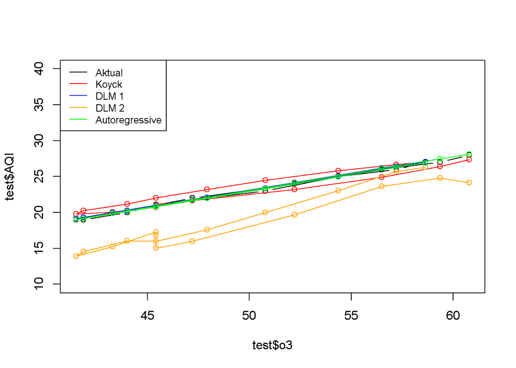

```r
par(mfrow=c(1,1))  # atur layout grafik tunggal

# plot data aktual
plot(test$o3, test$AQI, type="b", col="black", ylim=c(10,40))

# tambahkan garis ramalan dari masing-masing model
points(test$o3, fore.koyck$forecasts, col="red");   lines(test$o3, fore.koyck$forecasts, col="red")
points(test$o3, fore.dlm$forecasts, col="blue");    lines(test$o3, fore.dlm$forecasts, col="blue")
points(test$o3, fore.dlm2$forecasts, col="orange"); lines(test$o3, fore.dlm2$forecasts, col="orange")
points(test$o3, fore.ardl$forecasts, col="green");  lines(test$o3, fore.ardl$forecasts, col="green")

# legenda model
legend("topleft",
       c("Aktual", "Koyck","DLM 1","DLM 2", "Autoregressive"),
       lty=1, col=c("black","red","blue","orange","green"), cex=0.8)
```